# COMBINE R Workshop 2022 - Day 1

Mikhail Dias

09/02/2022

## Variables

*Variables* is the name given to a value.

We can create a new variable by using **<-** or **=** to assign it to a value.

*Note: In this tutorial we will be using <- to assign variables*

```r
width <- 5
```

There are some rules when generating variable names.

- Variable Rules:
  - Spaces are not allowed inside variable names.
  - Punctuation is not allowed within variable names.
    - Exception to this rule is using . or _
  - Numbers are allowed, except as the first character.

**Variable with space**

```r
my width <- 5
```

```
## Error: <text>:1:4: unexpected symbol
## 1: my width
##        ^
```

*Allowed Alternative:*

```r
my_width <- 5
```

**Variable with invalid punctuation**

```r
my,width <- 5
```

```
## Error: <text>:1:3: unexpected ','
## 1: my,
##       ^
```

*Allowed Alternative:*

```r
my.width <- 5
my_width <- 5
```

**Variable with number as the first character**

```r
2width <- 5
```

```
## Error: <text>:1:2: unexpected symbol
## 1: 2width
##      ^
```

*Allowed Alternative:*

```r
width2 <- 5
```

So…What is the use of assigning variables?

We can use variables in basic arithmetic equations.

*Area(Square) = height x width.*

```r
# Calculate the area of a square.

### Remove for tutorial ###
area = width*width
area = width^2
```

The values assigned to variables can also be changed.

```r
width <- 10

width
```

```
## [1] 10
```

```r
area
```

```
## [1] 25
```

Notice that the value of **“area”** has not changed from the value we previously calculated before we assigned a new value to **“width”**.

## Vectors

A vector of numbers is a collection of numbers. **Vector** means different things in different fields (mathematics, geometry, biology), but in *R* it is a fancy name for a collection of numbers. We call the individual number elements of the vector.

We can make vectors with c( ), for example *“c(1,2,3)”*. In R, **c** means *“combine”*. R is obsessed with vectors, in R even single numbers are vectors of length one. Many things that can be done with a single number can also be done with a vector. For example, arithmetic can be done on vectors as it can be single numbers.

```r
my_vector <- c(10 ,20 ,30 ,40 ,50)
my_vector
```

```
## [1] 10 20 30 40 50
```

```r
my_vector + 1
```

```
## [1] 11 21 31 41 51
```

```r
my_vector + my_vector
```

```
## [1]  20  40  60  80 100
```

```r
length(my_vector)
```

```
## [1] 5
```

```r
c(60, my_vector)
```

```
## [1] 60 10 20 30 40 50
```

```r
c(my_vector, 60)
```

```
## [1] 10 20 30 40 50 60
```

## Basic Data Types In R

To take complete advantage of the R language, you’ll need a strong understanding of the basic data types and data structures and how to effectively use them.

Data structures are very important to understand because these are the objects you will manipulate on a day-to-day basis in R. Dealing with object conversions is one of the most common sources of frustration for beginners.

**R has 6 basic data types.** (Note: In addition to the five listed below, there is also raw which will not be discussed in this workshop)

- character:“a”, “bcd”
- numeric: (real or decimal) 2, 15.5
- integer: 2L (the L tells R to store this as an integer)
- logical: TRUE, FALSE
- complex: 1 + 4i

If we want to check the object’s data we can use the R function “typeof()”

For example:

```r
x <- "dataset"
typeof(x)
```

```
## [1] "character"
```

```r
x <- 1L
typeof(x)
```

```
## [1] "integer"
```

```r
x <- 2> 1
x
```

```
## [1] TRUE
```

```r
typeof(x)
```

```
## [1] "logical"
```

## Types of vectors

We will also encounter vectors of character strings, for example:

```r
c("hello","world")
```

```
## [1] "hello" "world"
```

Or logical vectors:

```r
c(TRUE, TRUE, FALSE, TRUE)
```

```
## [1]  TRUE  TRUE FALSE  TRUE
```

Can you have a vector with mixing types?

```r
c(2, "hello")
```

```
## [1] "2"     "hello"
```

Because vectors can only contain one class of data type, R chooses a lowest common denominator type of vector, a type that can contain everything we are trying to put in it. A different language might stop with an error, but R tries to soldier on as best it can. A number can be represented as a character string, but a character string can not be represented as a number, so when we try to put both in the same vector R converts everything to a character string.

## Indexing vectors

Access elements of a vector with [ ], for example my_vector[1] to get the first element. You can also assign to a specific element of a vector.

```r
my_vector[1]
```

```
## [1] 10
```

Try changing the second element of `my_vector` to 5!

We can also use a vector to index another vector!

```r
my_index <- c(4,3,2)
my_vector[my_index]
```

```
## [1] 40 30 20
```

We can create and index character vectors as well. A cafe is using R to create their menu.

```r
items <- c("spam", "eggs", "beans", "bacon", "sausage")
```

What does items[-3] produce? Based on what you find, use indexing to create a version of items without “spam”.

Use indexing to create a vector containing spam, eggs, sausage, spam, and spam.

Add a new item, “lobster”, to items.

## Sequences

Another way to create a vector is with `:` :

```r
c(1:10)
```

```
##  [1]  1  2  3  4  5  6  7  8  9 10
```

This can be useful when combined with indexing:

```r
items[1:4]
```

```
## [1] "spam"  "eggs"  "beans" "bacon"
```

## Functions

Functions are the things that do all the work for us in R: calculate, manipulate data, read and write to files, produce plots. R has many built in functions and we will also be loading more specialized functions from “packages”.

We’ve already seen several functions: c( ), length( ). Let’s now have a look at sum( ).

```r
sum(my_vector)
```

```
## [1] 150
```

```r
?sum
```

Some functions take more than one argument. Let’s look at the function rep, which means “repeat”, and which can take a variety of different arguments. In the simplest case, it takes a value and the number of times to repeat that value.

```r
rep(42, 10)
```

```
##  [1] 42 42 42 42 42 42 42 42 42 42
```

As with many functions in R (which is obsessed with vectors) the thing to be repeated can be a vector with multiple elements.

```r
rep(c(1,2,3), 10)
```

```
##  [1] 1 2 3 1 2 3 1 2 3 1 2 3 1 2 3 1 2 3 1 2 3 1 2 3 1 2 3 1 2 3
```

R packages are collections of functions and data sets developed by the community. They increase the power of R by improving existing base R functionalities, or by adding new ones. For example, if you are usually working with data frames, probably you will have heard about dplyr or data.table, two of the most popular R packages.  
- If required, install packages using the “install.packages( )” function.

```r
# install.packages("dplyr")
# install.packages(c("dplyr", "data.table"))
```

```r
library(dplyr)
library(data.table)
```

Here we can install packages from CRAN. We can also install packages from bioconductor and github.

CRAN: the official repository, it is a network of ftp and web servers maintained by the R community around the world. The R foundation coordinates it, and for a package to be published here, it needs to pass several tests that ensure the package is following CRAN policies. You can find more details here.

Bioconductor: this is a topic specific repository, intended for open source software for bioinformatics. As CRAN, it has its own submission and review processes, and its community is very active having several conferences and meetings per year.

Github : although this is not R specific, Github is probably the most popular repository for open source projects. Its popularity comes from the unlimited space for open source, the integration with git, a version control software, and its ease to share and collaborate with others. But be aware that there is no review process associated with it.

In the case of Bioconductor, the standard way of installing a package is by first executing the following script:

```r
if (!requireNamespace("BiocManager", quietly = TRUE))
    install.packages("BiocManager")
```

This will install the tool that we are going to use to install Bioconductor packages: BiocManager. If you want to install the core packages of Bioconductor just type it without further arguments:

```r
BiocManager::install()
```

If, however, you are interested in just a few particular packages from this repository you can type their names directly as a character vector:

```r
BiocManager::install(c("GenomicFeatures", "AnnotationDbi"))
```

## *Practice Questions*

**Questions: Part 1**  
Use sum to sum from 1 to 10,000.

Take the cumulative sum of my_vector created earlier. Hint: Google to find the right function to use.

Find the average and standard deviation of my_vector created earlier.

Look at the documentation for the seq function. What does seq do? Give an example of using seq with either the by or length.out argument.

## Data Frames

*Data frame* is R’s name for tabular data. We generally want each row in a data frame to represent a unit of observation, and each column to contain a different type of information about the units of observation. Tabular data in this form is called [“tidy data”](http://vita.had.co.nz/papers/tidy-data.html).

Today we will be using a collection of modern packages collectively known as the [Tidyverse](https://www.tidyverse.org/). R and its predecessor S have a history dating back to 1976. The Tidyverse fixes some dubious design decisions baked into “base R”, including having its own slightly improved form of data frame, which is called a *tibble*. Sticking to the Tidyverse where possible is generally safer, Tidyverse packages are more willing to generate errors rather than ignore problems.

## Setting up

Our first step is to download the files we need and to install the Tidyverse. This is the one step where we ask you to copy and paste some code:

```r
# Download files for this workshop
download.file(
  "https://monashdatafluency.github.io/r-intro-2/r-intro-2-files.zip",
  destfile="r-intro-2-files.zip")
unzip("r-intro-2-files.zip")

# Install Tidyverse
install.packages("tidyverse")
```

If using RStudio Cloud, you might need to switch to R version 3.5.3 to successfully install Tidyverse. Use the drop-down in the top right corner of the page.

People also sometimes have problems installing all the packages in Tidyverse on Windows machines. If you run into problems you may have more success installing individual packages.

```r
install.packages(c("dplyr","readr","tidyr","ggplot2"))
```

We need to load the `tidyverse` package in order to use it.

```r
library(tidyverse)

# OR
library(dplyr)
library(readr)
library(tidyr)
library(ggplot2)
```

The `tidyverse` package loads various other packages, setting up a modern R environment. In this section we will be using functions from the `dplyr`, `readr` and `tidyr` packages.

R is a language with mini-languages within it that solve specific problem domains. `dplyr` is such a mini-language, a set of “verbs” (functions) that work well together. `dplyr`, with the help of `tidyr` for some more complex operations, provides a way to perform most manipulations on a data frame that you might need.

## Loading data

We will use the `read_csv` function from `readr` to load a data set. (See also `read.csv` in base R.) CSV stands for Comma Separated Values, and is a text format used to store tabular data. The first few lines of the file we are loading are shown below. Conventionally the first line contains column headings.

```
name,region,oecd,g77,lat,long,income2017
Afghanistan,asia,FALSE,TRUE,33,66,low
Albania,europe,FALSE,FALSE,41,20,upper_mid
Algeria,africa,FALSE,TRUE,28,3,upper_mid
Andorra,europe,FALSE,FALSE,42.50779,1.52109,high
Angola,africa,FALSE,TRUE,-12.5,18.5,lower_mid
```

```r
geo <- read_csv("r-intro-2-files/geo.csv")
geo
```

```
## # A tibble: 196 × 7
##    name                region   oecd  g77     lat   long income2017
##    <chr>               <chr>    <lgl> <lgl> <dbl>  <dbl> <chr>
##  1 Afghanistan         asia     FALSE TRUE   33    66    low
##  2 Albania             europe   FALSE FALSE  41    20    upper_mid
##  3 Algeria             africa   FALSE TRUE   28     3    upper_mid
##  4 Andorra             europe   FALSE FALSE  42.5   1.52 high
##  5 Angola              africa   FALSE TRUE  -12.5  18.5  lower_mid
##  6 Antigua and Barbuda americas FALSE TRUE   17.0 -61.8  high
##  7 Argentina           americas FALSE TRUE  -34   -64    upper_mid
##  8 Armenia             europe   FALSE FALSE  40.2  45    lower_mid
##  9 Australia           asia     TRUE  FALSE -25   135    high
## 10 Austria             europe   TRUE  FALSE  47.3  13.3  high
## # … with 186 more rows
```

`read_csv` has guessed the type of data each column holds:

- `<chr>` - character strings
- `<dbl>` - numerical values. Technically these are “doubles”, which is a way of storing numbers with 15 digits precision.
- `<lgl>` - logical values, `TRUE` or `FALSE`.

We will also encounter:

- `<int>` - integers, a fancy name for whole numbers.
- `<fct>` - factors, categorical data. We will get to this shortly.

You can also see this data frame referring to itself as “a tibble”. This is the Tidyverse’s improved form of data frame. Tibbles present themselves more conveniently than base R data frames. Base R data frames don’t show the type of each column, and output every row when you try to view them.

### Tip

A data frame can also be created from vectors, with the `tibble` function. (See also `data.frame` in base R.) For example:

```r
tibble(foo=c(10,20,30), bar=c("a","b","c"))
```

```
## # A tibble: 3 × 2
##     foo bar
##   <dbl> <chr>
## 1    10 a
## 2    20 b
## 3    30 c
```

The argument names become column names in the data frame.

## Exploring

The `View` function gives us a spreadsheet-like view of the data frame.

```
View(geo)
```

`print` with the `n` argument can be used to show more than the first 10 rows on the console.

```r
print(geo, n=200)
```

We can extract details of the data frame with further functions:

```r
nrow(geo)
```

```
## [1] 196
```

```r
ncol(geo)
```

```
## [1] 7
```

```r
colnames(geo)
```

```
## [1] "name"       "region"     "oecd"       "g77"        "lat"
## [6] "long"       "income2017"
```

```r
summary(geo)
```

```
##      name              region             oecd            g77
##  Length:196         Length:196         Mode :logical   Mode :logical
##  Class :character   Class :character   FALSE:165       FALSE:65
##  Mode  :character   Mode  :character   TRUE :31        TRUE :131
##
##
##
##       lat              long           income2017
##  Min.   :-42.00   Min.   :-175.000   Length:196
##  1st Qu.:  4.00   1st Qu.:  -5.625   Class :character
##  Median : 17.42   Median :  21.875   Mode  :character
##  Mean   : 19.03   Mean   :  23.004
##  3rd Qu.: 39.82   3rd Qu.:  51.892
##  Max.   : 65.00   Max.   : 179.145
```

## Indexing data frames

Data frames can be subset using `[row,column]` syntax.

```r
geo[4,2]
```

```
## # A tibble: 1 × 1
##   region
##   <chr>
## 1 europe
```

Note that while this is a single value, it is still wrapped in a data frame. (This is a behaviour specific to Tidyverse data frames.) More on this in a moment.

Columns can be given by name.

```r
geo[4,"region"]
```

```
## # A tibble: 1 × 1
##   region
##   <chr>
## 1 europe
```

The column or row may be omitted, thereby retrieving the entire row or column.

```r
geo[4,]
```

```
## # A tibble: 1 × 7
##   name    region oecd  g77     lat  long income2017
##   <chr>   <chr>  <lgl> <lgl> <dbl> <dbl> <chr>
## 1 Andorra europe FALSE FALSE  42.5  1.52 high
```

```r
geo[,"region"]
```

```
## # A tibble: 196 × 1
##    region
##    <chr>
##  1 asia
##  2 europe
##  3 africa
##  4 europe
##  5 africa
##  6 americas
##  7 americas
##  8 europe
##  9 asia
## 10 europe
## # … with 186 more rows
```

Multiple rows or columns may be retrieved using a vector.

```r
rows_wanted <- c(1,3,5)
geo[rows_wanted,]
```

```
## # A tibble: 3 × 7
##   name        region oecd  g77     lat  long income2017
##   <chr>       <chr>  <lgl> <lgl> <dbl> <dbl> <chr>
## 1 Afghanistan asia   FALSE TRUE   33    66   low
## 2 Algeria     africa FALSE TRUE   28     3   upper_mid
## 3 Angola      africa FALSE TRUE  -12.5  18.5 lower_mid
```

Vector indexing can also be written on a single line.

```r
geo[c(1,3,5),]
```

```
## # A tibble: 3 × 7
##   name        region oecd  g77     lat  long income2017
##   <chr>       <chr>  <lgl> <lgl> <dbl> <dbl> <chr>
## 1 Afghanistan asia   FALSE TRUE   33    66   low
## 2 Algeria     africa FALSE TRUE   28     3   upper_mid
## 3 Angola      africa FALSE TRUE  -12.5  18.5 lower_mid
```

```r
geo[1:7,]
```

```
## # A tibble: 7 × 7
##   name                region   oecd  g77     lat   long income2017
##   <chr>               <chr>    <lgl> <lgl> <dbl>  <dbl> <chr>
## 1 Afghanistan         asia     FALSE TRUE   33    66    low
## 2 Albania             europe   FALSE FALSE  41    20    upper_mid
## 3 Algeria             africa   FALSE TRUE   28     3    upper_mid
## 4 Andorra             europe   FALSE FALSE  42.5   1.52 high
## 5 Angola              africa   FALSE TRUE  -12.5  18.5  lower_mid
## 6 Antigua and Barbuda americas FALSE TRUE   17.0 -61.8  high
## 7 Argentina           americas FALSE TRUE  -34   -64    upper_mid
```

## Columns are vectors

Ok, so how do we actually get data out of a data frame?

Under the hood, a data frame is a list of column vectors. We can use `$` to retrieve columns. Occasionally it is also useful to use `[[ ]]` to retrieve columns, for example if the column name we want is stored in a variable.

```r
head( geo$region )
```

```
## [1] "asia"     "europe"   "africa"   "europe"   "africa"   "americas"
```

```r
head( geo[["region"]] )
```

```
## [1] "asia"     "europe"   "africa"   "europe"   "africa"   "americas"
```

To get the “region” value of the 4th row as above, but unwrapped, we can use:

```r
geo$region[4]
```

```
## [1] "europe"
```

For example, to plot the longitudes and latitudes we could use:

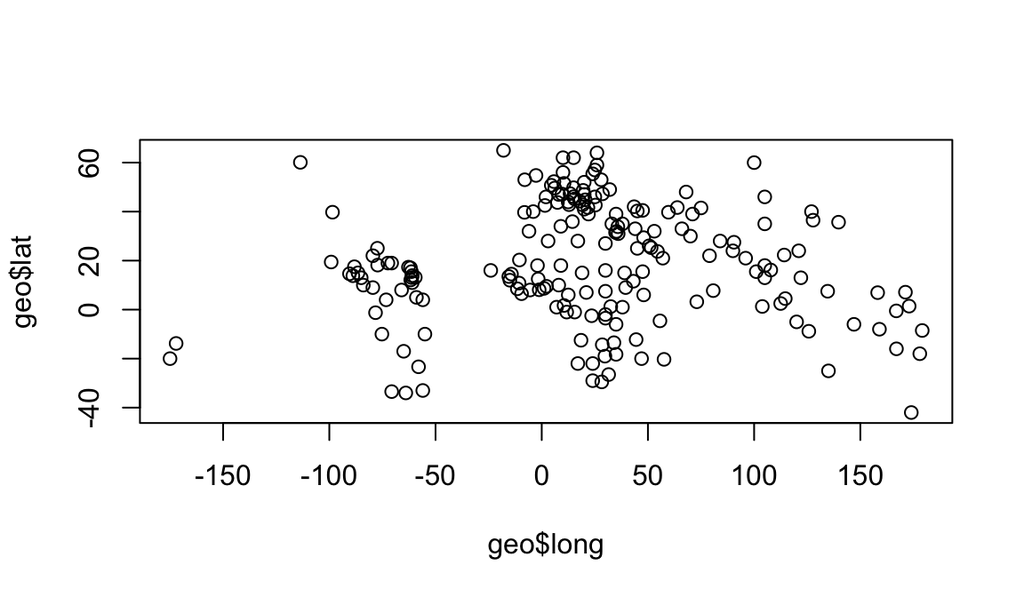

```r
plot(geo$long, geo$lat)
```

### Quiz: Reading R Code

You encounter some wild R code, and aren’t sure what it does. Based on R syntax you’ve encountered so far, what roles are the different names in this code playing?

```
highest <- geo$name[ head(order(geo$lat, decreasing=TRUE), n=10) ]
```

Find all examples of:

A. The name of a variable to store a value to.  
B. The name of a variable to retrieve the value from.  
C. The name of a column to get from a data frame.  
D. The name of a function to call.  
E. The name of an argument to a function call.

See [here](https://monashdatafluency.github.io/r-intro-2/answers-reading-r-code.html) for answers.

## Logical indexing

A method of indexing that we haven’t discussed yet is logical indexing. Instead of specifying the row number or numbers that we want, we can give a logical vector which is `TRUE` for the rows we want and `FALSE` otherwise. This can also be used with vectors.

We will first do this in a slightly verbose way in order to understand it, then learn a more concise way to do this using the `dplyr` package.

Southern countries have latitude less than zero.

```r
is_southern <- geo$lat < 0

head(is_southern)
```

```
## [1] FALSE FALSE FALSE FALSE  TRUE FALSE
```

```r
sum(is_southern)
```

```
## [1] 40
```

`sum` treats TRUE as 1 and FALSE as 0, so it tells us the number of TRUE elements in the vector.

We can use this logical vector to get the southern countries from `geo`:

```r
geo[is_southern,]
```

```
## # A tibble: 40 × 7
##    name             region   oecd  g77     lat  long income2017
##    <chr>            <chr>    <lgl> <lgl> <dbl> <dbl> <chr>
##  1 Angola           africa   FALSE TRUE  -12.5  18.5 lower_mid
##  2 Argentina        americas FALSE TRUE  -34   -64   upper_mid
##  3 Australia        asia     TRUE  FALSE -25   135   high
##  4 Bolivia          americas FALSE TRUE  -17   -65   lower_mid
##  5 Botswana         africa   FALSE TRUE  -22    24   upper_mid
##  6 Brazil           americas FALSE TRUE  -10   -55   upper_mid
##  7 Burundi          africa   FALSE TRUE   -3.5  30   low
##  8 Chile            americas TRUE  TRUE  -33.5 -70.6 high
##  9 Comoros          africa   FALSE TRUE  -12.2  44.4 low
## 10 Congo, Dem. Rep. africa   FALSE TRUE   -2.5  23.5 low
## # … with 30 more rows
```

Comparison operators available are:

- `x == y` – “equal to”
- `x != y` – “not equal to”
- `x < y` – “less than”
- `x > y` – “greater than”
- `x <= y` – “less than or equal to”
- `x >= y` – “greater than or equal to”

More complicated conditions can be constructed using logical operators:

- `a & b` – “and”, TRUE only if both `a` and `b` are TRUE.
- `a | b` – “or”, TRUE if either `a` or `b` or both are TRUE.
- `! a` – “not” , TRUE if `a` is FALSE, and FALSE if `a` is TRUE.

The `oecd` column of `geo` tells which countries are in the Organisation for Economic Co-operation and Development, and the `g77` column tells which countries are in the Group of 77 (an alliance of developing nations). We could see which OECD countries are in the southern hemisphere with:

```r
southern_oecd <- is_southern & geo$oecd

geo[southern_oecd,]
```

```
## # A tibble: 3 × 7
##   name        region   oecd  g77     lat  long income2017
##   <chr>       <chr>    <lgl> <lgl> <dbl> <dbl> <chr>
## 1 Australia   asia     TRUE  FALSE -25   135   high
## 2 Chile       americas TRUE  TRUE  -33.5 -70.6 high
## 3 New Zealand asia     TRUE  FALSE -42   174   high
```

`is_southern` seems like it should be kept within our `geo` data frame for future use. We can add it as a new column of the data frame with:

```r
geo$southern <- is_southern

geo
```

```
## # A tibble: 196 × 8
##    name                region   oecd  g77     lat   long income2017 southern
##    <chr>               <chr>    <lgl> <lgl> <dbl>  <dbl> <chr>      <lgl>
##  1 Afghanistan         asia     FALSE TRUE   33    66    low        FALSE
##  2 Albania             europe   FALSE FALSE  41    20    upper_mid  FALSE
##  3 Algeria             africa   FALSE TRUE   28     3    upper_mid  FALSE
##  4 Andorra             europe   FALSE FALSE  42.5   1.52 high       FALSE
##  5 Angola              africa   FALSE TRUE  -12.5  18.5  lower_mid  TRUE
##  6 Antigua and Barbuda americas FALSE TRUE   17.0 -61.8  high       FALSE
##  7 Argentina           americas FALSE TRUE  -34   -64    upper_mid  TRUE
##  8 Armenia             europe   FALSE FALSE  40.2  45    lower_mid  FALSE
##  9 Australia           asia     TRUE  FALSE -25   135    high       TRUE
## 10 Austria             europe   TRUE  FALSE  47.3  13.3  high       FALSE
## # … with 186 more rows
```

### Challenge: Logical Indexing

1. Which country is in both the OECD and the G77?
2. Which countries are in neither the OECD nor the G77?
3. Which countries are in the Americas? These have longitudes between -150 and -40.

### A `dplyr` shorthand

The above method is a little laborious. We have to keep mentioning the name of the data frame, and there is a lot of punctuation to keep track of. `dplyr` provides a slightly magical function called `filter` which lets us write more concisely. For example:

```r
filter(geo, lat < 0 & oecd)
```

```
## # A tibble: 3 × 8
##   name        region   oecd  g77     lat  long income2017 southern
##   <chr>       <chr>    <lgl> <lgl> <dbl> <dbl> <chr>      <lgl>
## 1 Australia   asia     TRUE  FALSE -25   135   high       TRUE
## 2 Chile       americas TRUE  TRUE  -33.5 -70.6 high       TRUE
## 3 New Zealand asia     TRUE  FALSE -42   174   high       TRUE
```

In the second argument, we are able to refer to columns of the data frame as though they were variables. The code is beautiful, but also opaque. It’s important to understand that under the hood we are creating and combining logical vectors.

## Factors

The `count` function from `dplyr` can help us understand the contents of some of the columns in `geo`. `count` is also *magical*, we can refer to columns of the data frame directly in the arguments to `count`.

```r
count(geo, region)
```

```
## # A tibble: 4 × 2
##   region       n
##   <chr>    <int>
## 1 africa      54
## 2 americas    35
## 3 asia        59
## 4 europe      48
```

```r
count(geo, income2017)
```

```
## # A tibble: 4 × 2
##   income2017     n
##   <chr>      <int>
## 1 high          58
## 2 low           31
## 3 lower_mid     52
## 4 upper_mid     55
```

One annoyance here is that the different categories in `income2017` aren’t in a sensible order. This comes up quite often, for example when sorting or plotting categorical data. R’s solution is a further type of vector called a *factor* (think a factor of an experimental design). A factor holds categorical data, and has an associated ordered set of *levels*. It is otherwise quite similar to a character vector.

Any sort of vector can be converted to a factor using the `factor` function. This function defaults to placing the levels in alphabetical order, but takes a `levels` argument that can override this.

```r
head( factor(geo$income2017, levels=c("low","lower_mid","upper_mid","high")) )
```

```
## [1] low       upper_mid upper_mid high      lower_mid high
## Levels: low lower_mid upper_mid high
```

We should modify the `income2017` column of the `geo` table in order to use this:

```r
geo$income2017 <- factor(geo$income2017, levels=c("low","lower_mid","upper_mid","high"))
```

`count` now produces the desired order of output:

```r
count(geo, income2017)
```

```
## # A tibble: 4 × 2
##   income2017     n
##   <fct>      <int>
## 1 low           31
## 2 lower_mid     52
## 3 upper_mid     55
## 4 high          58
```

When `plot` is given a factor, it shows a bar plot:

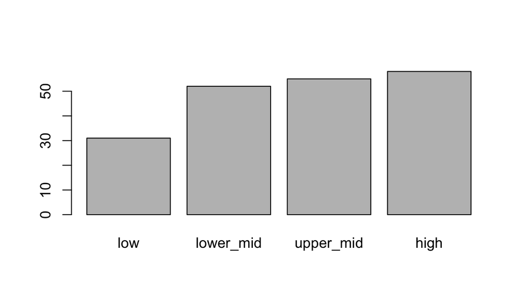

```r
plot(geo$income2017)
```

When given two factors, it shows a mosaic plot:

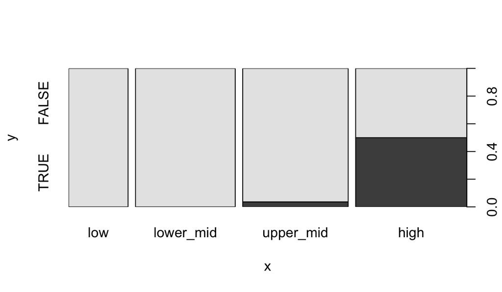

```r
plot(geo$income2017, factor(geo$oecd))
```

Similarly we can count two categorical columns at once.

```r
count(geo, income2017, oecd)
```

```
## # A tibble: 6 × 3
##   income2017 oecd      n
##   <fct>      <lgl> <int>
## 1 low        FALSE    31
## 2 lower_mid  FALSE    52
## 3 upper_mid  FALSE    53
## 4 upper_mid  TRUE      2
## 5 high       FALSE    29
## 6 high       TRUE     29
```

## Readability vs Tidyness

The counts we obtained counting `income2017` vs `oecd` were properly tidy in the sense of containing a single unit of observation per row. However to view the data, it would be more convenient to have income as columns and OECD membership as rows. We can use the `pivot_wider` function from `tidyr` to achieve this. (This is also sometimes also called a “cast” or a “spread”.)

```r
counts <- count(geo, income2017, oecd)
pivot_wider(counts, names_from=income2017, values_from=n)
```

```
## # A tibble: 2 × 5
##   oecd    low lower_mid upper_mid  high
##   <lgl> <int>     <int>     <int> <int>
## 1 FALSE    31        52        53    29
## 2 TRUE     NA        NA         2    29
```

We could further specify `values_fill=list(n=0)` to fill in the `NA` values with 0.

### Tip

Tidying is often the first step when exploring a data-set. The [tidyr](http://tidyr.tidyverse.org/) package contains a number of useful functions that help tidy (or un-tidy!) data. We’ve just seen `pivot_wider` which spreads two columns into multiple columns. The inverse of `pivot_wider` is `pivot_longer`, which gathers multiple columns into two columns: a column of column names, and a column of values. `pivot_longer` is often the first step when tidying a dataset you have received from the wild. (This is sometimes also called a “melt” or a “gather”.)

### Challenge: Counting

Investigate how many OECD and non-OECD nations come from the northern and southern hemispheres.

1. Using `count`.
2. By making a mosaic plot.

Remember you may need to convert columns to factors for `plot` to work, and that a `southern` column could be added to `geo` with:

```r
geo$southern <- geo$lat < 0
```

## Sorting

Data frames can be sorted using the `arrange` function in `dplyr`.

```r
arrange(geo, lat)
```

```
## # A tibble: 196 × 8
##    name         region   oecd  g77     lat  long income2017 southern
##    <chr>        <chr>    <lgl> <lgl> <dbl> <dbl> <fct>      <lgl>
##  1 New Zealand  asia     TRUE  FALSE -42   174   high       TRUE
##  2 Argentina    americas FALSE TRUE  -34   -64   upper_mid  TRUE
##  3 Chile        americas TRUE  TRUE  -33.5 -70.6 high       TRUE
##  4 Uruguay      americas FALSE TRUE  -33   -56   high       TRUE
##  5 Lesotho      africa   FALSE TRUE  -29.5  28.2 lower_mid  TRUE
##  6 South Africa africa   FALSE TRUE  -29    24   upper_mid  TRUE
##  7 Swaziland    africa   FALSE TRUE  -26.5  31.5 lower_mid  TRUE
##  8 Australia    asia     TRUE  FALSE -25   135   high       TRUE
##  9 Paraguay     americas FALSE TRUE  -23.3 -58   upper_mid  TRUE
## 10 Botswana     africa   FALSE TRUE  -22    24   upper_mid  TRUE
## # … with 186 more rows
```

Numeric columns are sorted in numeric order. Character columns will be sorted in alphabetical order. Factor columns are sorted in order of their levels. The `desc` helper function can be used to sort in descending order.

```r
arrange(geo, desc(name))
```

```
## # A tibble: 196 × 8
##    name           region   oecd  g77     lat   long income2017 southern
##    <chr>          <chr>    <lgl> <lgl> <dbl>  <dbl> <fct>      <lgl>
##  1 Zimbabwe       africa   FALSE TRUE  -19    29.8  low        TRUE
##  2 Zambia         africa   FALSE TRUE  -14.3  28.5  lower_mid  TRUE
##  3 Yemen          asia     FALSE TRUE   15.5  47.5  lower_mid  FALSE
##  4 Vietnam        asia     FALSE TRUE   16.2 108.   lower_mid  FALSE
##  5 Venezuela      americas FALSE TRUE    8   -66    upper_mid  FALSE
##  6 Vanuatu        asia     FALSE TRUE  -16   167    lower_mid  TRUE
##  7 Uzbekistan     asia     FALSE FALSE  41.7  63.8  lower_mid  FALSE
##  8 Uruguay        americas FALSE TRUE  -33   -56    high       TRUE
##  9 United States  americas TRUE  FALSE  39.8 -98.5  high       FALSE
## 10 United Kingdom europe   TRUE  FALSE  54.8  -2.70 high       FALSE
## # … with 186 more rows
```

## Joining data frames

Let’s move on to a larger data set. This is from the [Gapminder](https://www.gapminder.org) project and contains information about countries over time.

```r
gap <- read_csv("r-intro-2-files/gap-minder.csv")
gap
```

```
## # A tibble: 4,312 × 5
##    name                 year population gdp_percap life_exp
##    <chr>               <dbl>      <dbl>      <dbl>    <dbl>
##  1 Afghanistan          1800    3280000        603     28.2
##  2 Albania              1800     410445        667     35.4
##  3 Algeria              1800    2503218        715     28.8
##  4 Andorra              1800       2654       1197     NA
##  5 Angola               1800    1567028        618     27.0
##  6 Antigua and Barbuda  1800      37000        757     33.5
##  7 Argentina            1800     534000       1507     33.2
##  8 Armenia              1800     413326        514     34
##  9 Australia            1800     351014        814     34.0
## 10 Austria              1800    3205587       1847     34.4
## # … with 4,302 more rows
```

### Quiz

What is the unit of observation in this new data frame?

It would be useful to have general information about countries from `geo` available as columns when we use this data frame. `gap` and `geo` share a column called `name` which can be used to match rows from one to the other.

```r
gap_geo <- left_join(gap, geo, by="name")
gap_geo
```

```
## # A tibble: 4,312 × 12
##    name      year population gdp_percap life_exp region oecd  g77     lat   long
##    <chr>    <dbl>      <dbl>      <dbl>    <dbl> <chr>  <lgl> <lgl> <dbl>  <dbl>
##  1 Afghani…  1800    3280000        603     28.2 asia   FALSE TRUE   33    66
##  2 Albania   1800     410445        667     35.4 europe FALSE FALSE  41    20
##  3 Algeria   1800    2503218        715     28.8 africa FALSE TRUE   28     3
##  4 Andorra   1800       2654       1197     NA   europe FALSE FALSE  42.5   1.52
##  5 Angola    1800    1567028        618     27.0 africa FALSE TRUE  -12.5  18.5
##  6 Antigua…  1800      37000        757     33.5 ameri… FALSE TRUE   17.0 -61.8
##  7 Argenti…  1800     534000       1507     33.2 ameri… FALSE TRUE  -34   -64
##  8 Armenia   1800     413326        514     34   europe FALSE FALSE  40.2  45
##  9 Austral…  1800     351014        814     34.0 asia   TRUE  FALSE -25   135
## 10 Austria   1800    3205587       1847     34.4 europe TRUE  FALSE  47.3  13.3
## # … with 4,302 more rows, and 2 more variables: income2017 <fct>,
## #   southern <lgl>
```

The output contains all ways of pairing up rows by `name`. In this case each row of `geo` pairs up with multiple rows of `gap`.

The “left” in “left join” refers to how rows that can’t be paired up are handled. `left_join` keeps all rows from the first data frame but not the second. This is a good default when the intent is to attaching some extra information to a data frame. `inner_join` discard all rows that can’t be paired up. `full_join` keeps all rows from both data frames.

Other joins: Check out this [“Animation”](https://www.linkedin.com/feed/update/urn:li:activity:6763045820590907392/)

## Further reading

We’ve covered the fundamentals of dplyr and data frames, but there is much more to learn. Notably, we haven’t covered the use of the pipe `%>%` to chain `dplyr` verbs together. The [“R for Data Science” book](http://r4ds.had.co.nz/) is an excellent source to learn more. The Monash Data Fluency [“Programming and Tidy data analysis in R” course](https://monashdatafluency.github.io/r-progtidy/) also covers this.